# NLP_Project_Full_Code_bpa_fixed

#### For each numerical feature, let's do a histogram and boxplot.

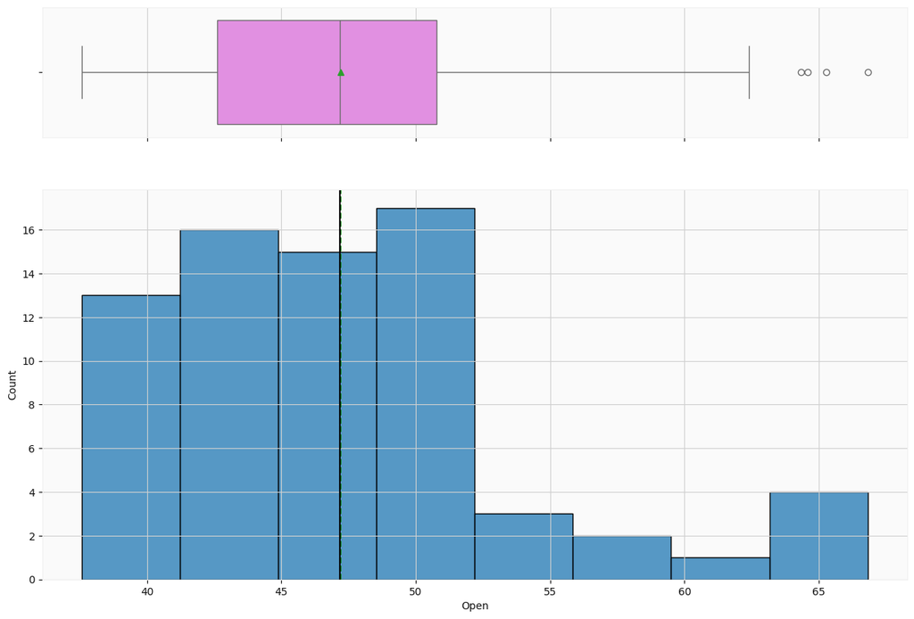

```python
histogram_boxplot(data_unique, 'Open')
```

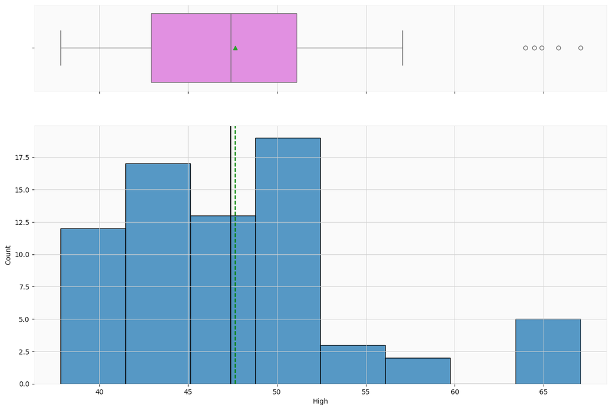

```python
histogram_boxplot(data_unique, 'High')
```

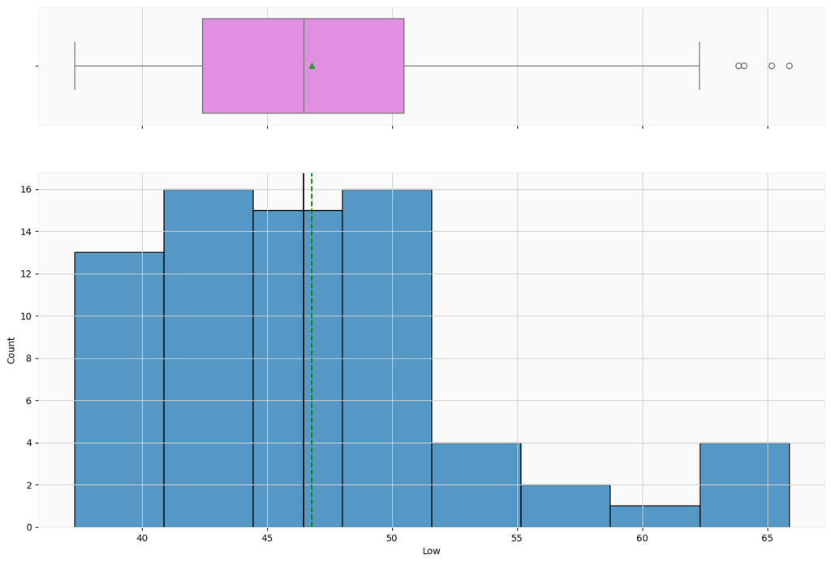

```python
histogram_boxplot(data_unique, 'Low')
```

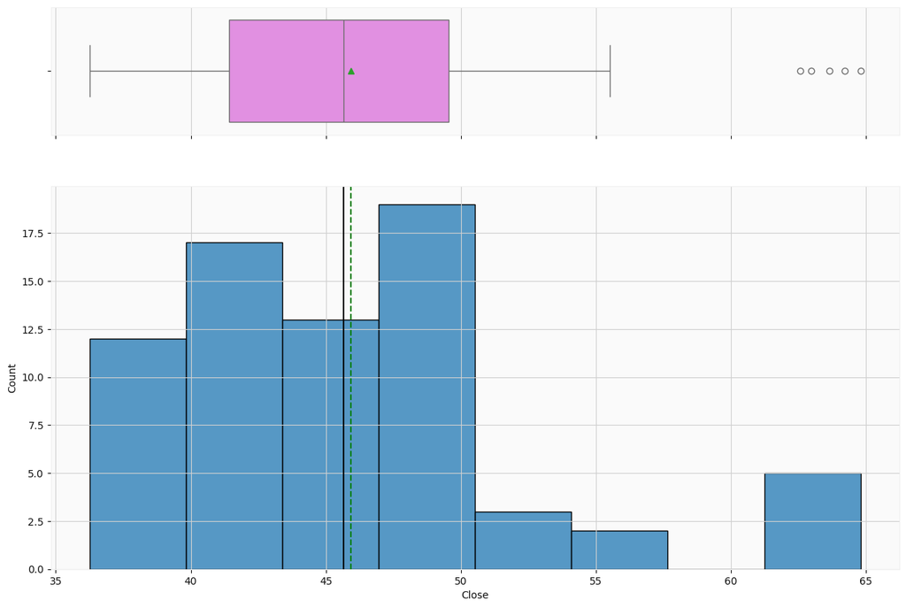

```python
histogram_boxplot(data_unique, 'Close')
```

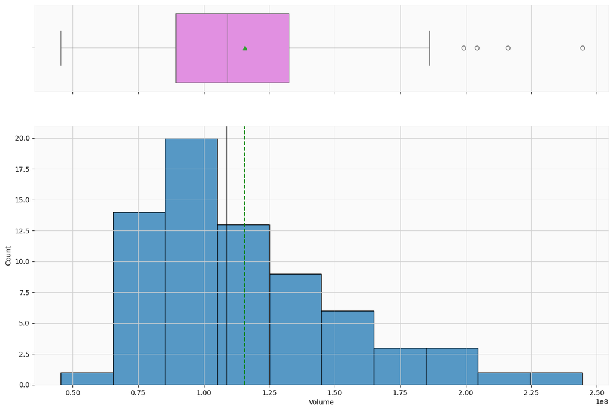

```python
histogram_boxplot(data_unique, 'Volume')
```

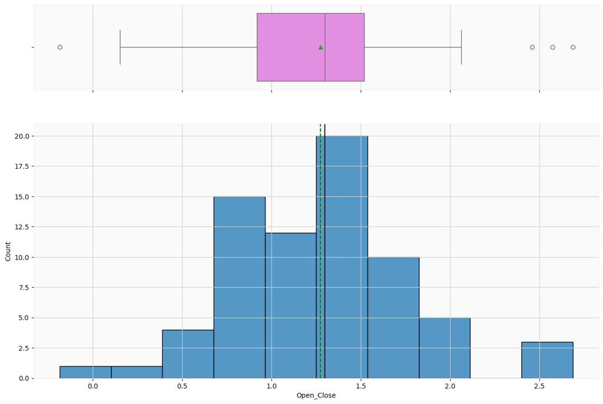

```python
histogram_boxplot(data_unique, 'Open_Close')
```

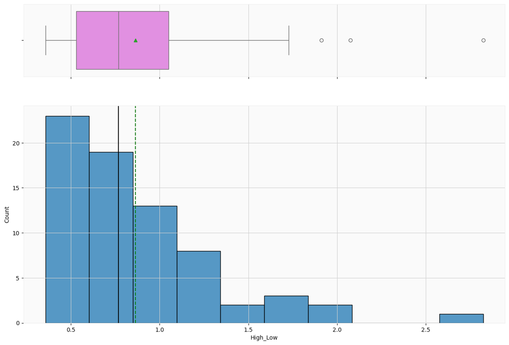

```python
histogram_boxplot(data_unique, 'High_Low')
```

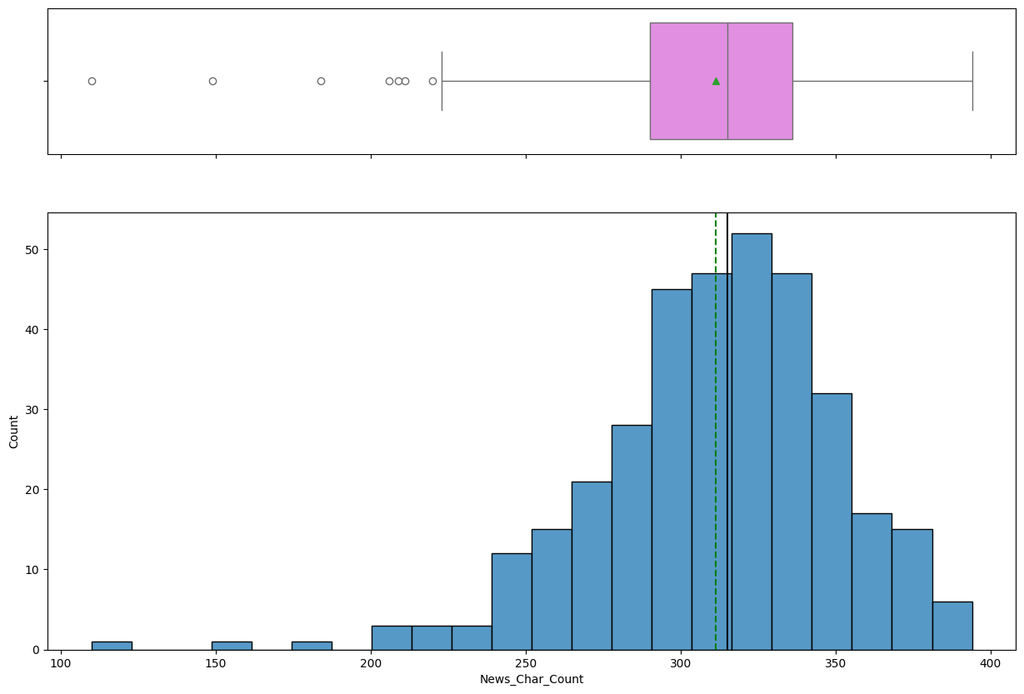

```python
histogram_boxplot(data, 'News_Char_Count')
```

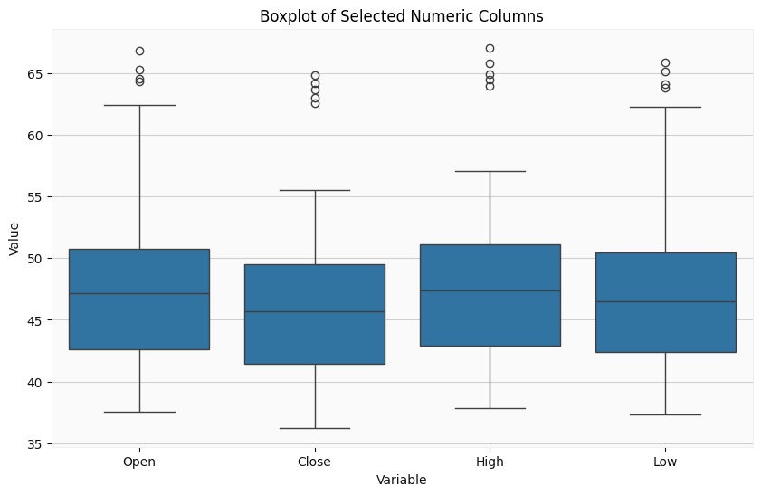

```python
# For easier comparison of the Open, Close, High, and Low values plot together on the same chart
# List of selected numeric columns
selected_columns = ['Open', 'Close', 'High', 'Low']

# Melt the DataFrame for easier boxplot handling
melted_data = data_unique[selected_columns].melt(var_name='Variable', value_name='Value')

# Create the boxplot
plt.figure(figsize=(10, 6))
sns.boxplot(x='Variable', y='Value', data=melted_data)
plt.title('Boxplot of Selected Numeric Columns')
plt.show()
```

### Bivariate Analysis

- Correlation
- Sentiment Polarity vs Price
- Date vs Price

**Note**: The above points are listed to provide guidance on how to approach bivariate analysis. Analysis has to be done beyond the above listed points to get maximum scores.

#### Let's see what the correlation looks like for the numeric data and colored based on the sentiment label.

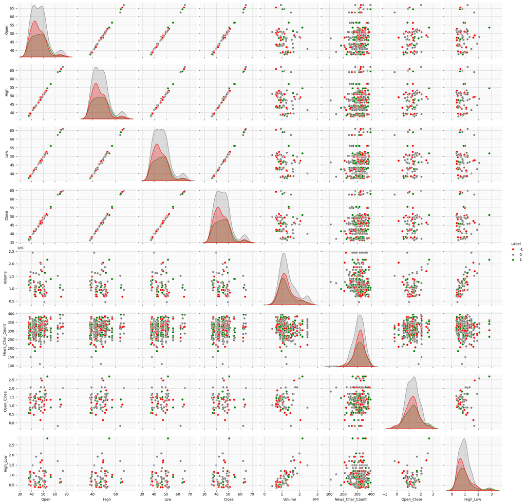

```python
# Define the color mapping
custom_palette = {-1: 'red', 0: 'gray', 1: 'green'}

# Scatter plot matrix
plt.figure(figsize=(12, 8))
sns.pairplot(data, vars=num_features, hue='Label', diag_kind='kde', palette=custom_palette);
```

From the above we can see that the Open, High, Low, and Close valies are all highly correlated. There is no discernible correlation with the Volume or New_Chart_Count value.

#### Let's look at how many news articles there are per week.

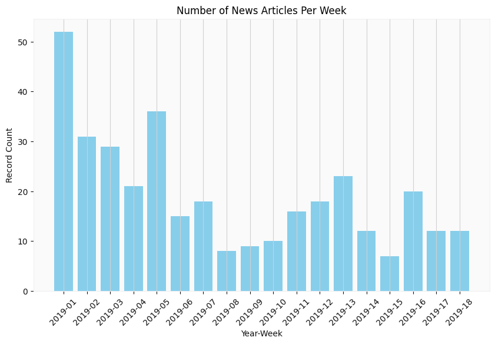

```python
# Extract the year and ISO week number
data['Year-Week'] = data['Date'].dt.isocalendar().year.astype(str) + '-' + data['Date'].dt.isocalendar().week.astype(str).str.zfill(2)

# Group by Year-Week and count the number of records
weekly_counts = data.groupby('Year-Week').size().reset_index(name='Count')

# Plot the counts
plt.figure(figsize=(10, 6))
plt.bar(weekly_counts['Year-Week'], weekly_counts['Count'], color='skyblue')
plt.title('Number of News Articles Per Week')
plt.xlabel('Year-Week')
plt.ylabel('Record Count')
plt.xticks(rotation=45)
plt.grid(axis='y')
plt.show()
```

We can see that the reviews range from Week #1-18 in 2019.

#### Correlation between Sentiment Polarity and Close Price

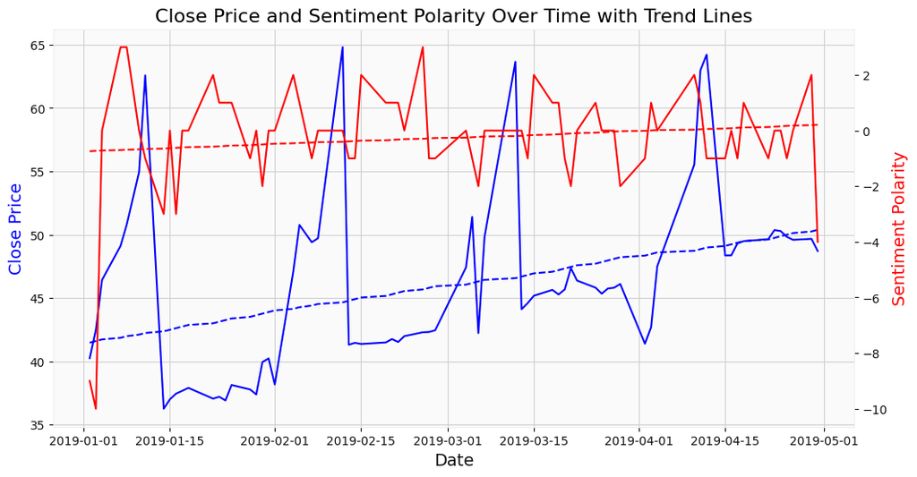

```python
fig, ax1 = plt.subplots(figsize=(12, 6))

# Plot Close price
ax1.plot(data_unique['Date'], data_unique['Close'], label='Close Price', color='blue')
ax1.set_xlabel('Date', fontsize=14)
ax1.set_ylabel('Close Price', color='blue', fontsize=14)

# Add trend line for Close price
x_close = np.arange(len(data_unique['Date']))  # Convert Date to a numeric range for regression
y_close = data_unique['Close']
coef_close = np.polyfit(x_close, y_close, 1)  # Fit a linear regression line
trend_close = np.polyval(coef_close, x_close)
ax1.plot(data_unique['Date'], trend_close, linestyle='--', color='blue', label='Trend Close Price')

# Plot Label_Sum on a secondary y-axis
ax2 = ax1.twinx()
ax2.plot(data_unique['Date'], data_unique['Label_Sum'], label='Sentiment Polarity', color='red')
ax2.set_ylabel('Sentiment Polarity', color='red', fontsize=14)

# Add trend line for Label_Sum
y_label_sum = data_unique['Label_Sum']
coef_label_sum = np.polyfit(x_close, y_label_sum, 1)  # Fit a linear regression line
trend_label_sum = np.polyval(coef_label_sum, x_close)
ax2.plot(data_unique['Date'], trend_label_sum, linestyle='--', color='red', label='Trend Sentiment Polarity')

# Add grid and title
plt.title('Close Price and Sentiment Polarity Over Time with Trend Lines', fontsize=16)
plt.grid()
plt.show()
```

While the data is quite eractic from day to day, we can see that there is a slight improvement per the trend line in the Sentiment Polarity for the day which corresponds in an upward trend line of the Close price.

#### Finance "candlestick" style chart to show the stock Open, High, Low, and Close price for each date.

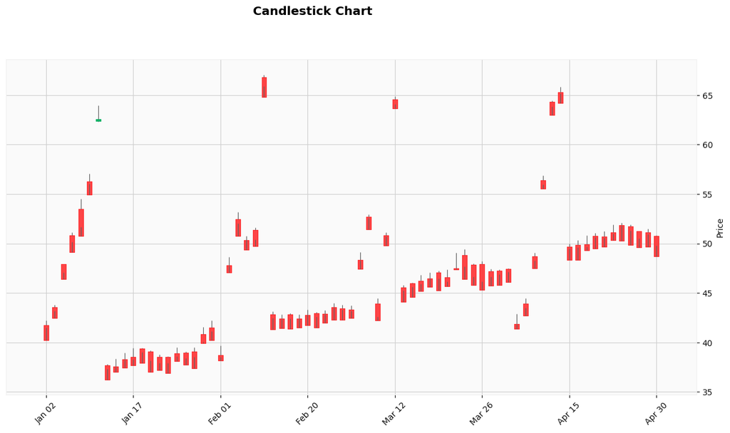

```python
# Subset the DataFrame
data_unique_sub = data_unique[['Open', 'High', 'Low', 'Close']]

# Plot the candlestick chart
mpf.plot(data_unique_sub, type='candle', title='Candlestick Chart', style='yahoo', figsize=(16, 8))
```

In the above chart the bars represent the difference between the Open and Close price (Red if Close < Open or Green if Close > Open). The upper wick represents the difference between the High to the higher of the Open or Close, while the lower wick represents the difference from the Low to the lower of Open or Close. **There is a problem with the data where in most cases the Close value is lower than the Low value which should not be possible.**

## **Data Preprocessing**

### **Removing special characters from the text**

```python
# defining a function to remove special characters
def remove_special_characters(text):
    # Defining the regex pattern to match non-alphanumeric characters
    pattern = '[^A-Za-z0-9]+'

    # Finding the specified pattern and replacing non-alphanumeric characters with a blank string
    new_text = ''.join(re.sub(pattern, ' ', text))

    return new_text
```

```python
# Applying the function to remove special characters
data['Cleaned_News'] = data['News'].apply(remove_special_characters)
```

```python
# checking a couple of instances of cleaned data
data.loc[0:3, ['News','Cleaned_News']]
```

|  | News | Cleaned_News |
| --- | --- | --- |
| 0 | The tech sector experienced a significant decline in the aftermarket following Apple's Q1 revenue warning. Notable suppliers, including Skyworks, Broadcom, Lumentum, Qorvo, and TSMC, saw their stocks … | The tech sector experienced a significant decline in the aftermarket following Apple s Q1 revenue warning Notable suppliers including Skyworks Broadcom Lumentum Qorvo and TSMC saw their stocks drop in… |
| 1 | Apple lowered its fiscal Q1 revenue guidance to $84 billion from earlier estimates of $89-$93 billion due to weaker than expected iPhone sales. The announcement caused a significant drop in Apple's st… | Apple lowered its fiscal Q1 revenue guidance to 84 billion from earlier estimates of 89 93 billion due to weaker than expected iPhone sales The announcement caused a significant drop in Apple s stock … |
| 2 | Apple cut its fiscal first quarter revenue forecast from $89-$93 billion to $84 billion due to weaker demand in China and fewer iPhone upgrades. CEO Tim Cook also mentioned constrained sales of Airpod… | Apple cut its fiscal first quarter revenue forecast from 89 93 billion to 84 billion due to weaker demand in China and fewer iPhone upgrades CEO Tim Cook also mentioned constrained sales of Airpods an… |
| 3 | This news article reports that yields on long-dated U.S. Treasury securities hit their lowest levels in nearly a year on January 2, 2019, due to concerns about the health of the global economy followi… | This news article reports that yields on long dated U S Treasury securities hit their lowest levels in nearly a year on January 2 2019 due to concerns about the health of the global economy following … |

### **Lowercasing**

```python
# changing the case of the text data to lower case
data['Cleaned_News'] = data['Cleaned_News'].str.lower()
```

```python
# checking a couple of instances of cleaned data
data.loc[0:3, ['News','Cleaned_News']]
```

|  | News | Cleaned_News |
| --- | --- | --- |
| 0 | The tech sector experienced a significant decline in the aftermarket following Apple's Q1 revenue warning. Notable suppliers, including Skyworks, Broadcom, Lumentum, Qorvo, and TSMC, saw their stocks … | the tech sector experienced a significant decline in the aftermarket following apple s q1 revenue warning notable suppliers including skyworks broadcom lumentum qorvo and tsmc saw their stocks drop in… |
| 1 | Apple lowered its fiscal Q1 revenue guidance to $84 billion from earlier estimates of $89-$93 billion due to weaker than expected iPhone sales. The announcement caused a significant drop in Apple's st… | apple lowered its fiscal q1 revenue guidance to 84 billion from earlier estimates of 89 93 billion due to weaker than expected iphone sales the announcement caused a significant drop in apple s stock … |
| 2 | Apple cut its fiscal first quarter revenue forecast from $89-$93 billion to $84 billion due to weaker demand in China and fewer iPhone upgrades. CEO Tim Cook also mentioned constrained sales of Airpod… | apple cut its fiscal first quarter revenue forecast from 89 93 billion to 84 billion due to weaker demand in china and fewer iphone upgrades ceo tim cook also mentioned constrained sales of airpods an… |
| 3 | This news article reports that yields on long-dated U.S. Treasury securities hit their lowest levels in nearly a year on January 2, 2019, due to concerns about the health of the global economy followi… | this news article reports that yields on long dated u s treasury securities hit their lowest levels in nearly a year on january 2 2019 due to concerns about the health of the global economy following … |

### **Removing extra whitespace**

```python
# removing extra whitespaces from the text
data['Cleaned_News'] = data['Cleaned_News'].str.strip()
```

```python
# checking a couple of instances of cleaned data
data.loc[0:3, ['News','Cleaned_News']]
```

|  | News | Cleaned_News |
| --- | --- | --- |
| 0 | The tech sector experienced a significant decline in the aftermarket following Apple's Q1 revenue warning. Notable suppliers, including Skyworks, Broadcom, Lumentum, Qorvo, and TSMC, saw their stocks … | the tech sector experienced a significant decline in the aftermarket following apple s q1 revenue warning notable suppliers including skyworks broadcom lumentum qorvo and tsmc saw their stocks drop in… |
| 1 | Apple lowered its fiscal Q1 revenue guidance to $84 billion from earlier estimates of $89-$93 billion due to weaker than expected iPhone sales. The announcement caused a significant drop in Apple's st… | apple lowered its fiscal q1 revenue guidance to 84 billion from earlier estimates of 89 93 billion due to weaker than expected iphone sales the announcement caused a significant drop in apple s stock … |
| 2 | Apple cut its fiscal first quarter revenue forecast from $89-$93 billion to $84 billion due to weaker demand in China and fewer iPhone upgrades. CEO Tim Cook also mentioned constrained sales of Airpod… | apple cut its fiscal first quarter revenue forecast from 89 93 billion to 84 billion due to weaker demand in china and fewer iphone upgrades ceo tim cook also mentioned constrained sales of airpods an… |
| 3 | This news article reports that yields on long-dated U.S. Treasury securities hit their lowest levels in nearly a year on January 2, 2019, due to concerns about the health of the global economy followi… | this news article reports that yields on long dated u s treasury securities hit their lowest levels in nearly a year on january 2 2019 due to concerns about the health of the global economy following … |

### **Removing stopwords**

- The idea with stop word removal is to **exclude words that appear frequently throughout** all the documents in the corpus.
- Pronouns and articles are typically categorized as stop words.
- The `NLTK` library has an in-built list of stop words and it can utilize that list to remove the stop words from a dataset.

```python
# defining a function to remove stop words using the NLTK library
def remove_stopwords(text):
    # Split text into separate words
    words = text.split()

    # Removing English language stopwords
    new_text = ' '.join([word for word in words if word not in stopwords.words('english')])

    return new_text
```

```python
# Applying the function to remove stop words using the NLTK library
data['Cleaned_News_without_stopwords'] = data['Cleaned_News'].apply(remove_stopwords)
```

```python
# checking a couple of instances of cleaned data
data.loc[0:3, ['Cleaned_News','Cleaned_News_without_stopwords']]
```

|  | Cleaned_News | Cleaned_News_without_stopwords |
| --- | --- | --- |
| 0 | the tech sector experienced a significant decline in the aftermarket following apple s q1 revenue warning notable suppliers including skyworks broadcom lumentum qorvo and tsmc saw their stocks drop in… | tech sector experienced significant decline aftermarket following apple q1 revenue warning notable suppliers including skyworks broadcom lumentum qorvo tsmc saw stocks drop response apple downward rev… |
| 1 | apple lowered its fiscal q1 revenue guidance to 84 billion from earlier estimates of 89 93 billion due to weaker than expected iphone sales the announcement caused a significant drop in apple s stock … | apple lowered fiscal q1 revenue guidance 84 billion earlier estimates 89 93 billion due weaker expected iphone sales announcement caused significant drop apple stock price negatively impacted related … |
| 2 | apple cut its fiscal first quarter revenue forecast from 89 93 billion to 84 billion due to weaker demand in china and fewer iphone upgrades ceo tim cook also mentioned constrained sales of airpods an… | apple cut fiscal first quarter revenue forecast 89 93 billion 84 billion due weaker demand china fewer iphone upgrades ceo tim cook also mentioned constrained sales airpods macbooks apple shares fell … |
| 3 | this news article reports that yields on long dated u s treasury securities hit their lowest levels in nearly a year on january 2 2019 due to concerns about the health of the global economy following … | news article reports yields long dated u treasury securities hit lowest levels nearly year january 2 2019 due concerns health global economy following weak economic data china europe well partial u go… |

### **Stemming**

Stemming is a language processing method that chops off word endings to find the root or base form of words.

For example,

- Original Word: Jumping, Stemmed Word: Jump
- Original Word: Running, Stemmed Word: Run

The Porter Stemmer is one of the widely-used algorithms for stemming, and it shorten words to their root form by removing suffixes.

```python
# Loading the Porter Stemmer
ps = PorterStemmer()
```

```python
# defining a function to perform stemming
def apply_porter_stemmer(text):
    # Split text into separate words
    words = text.split()

    # Applying the Porter Stemmer on every word of a message and joining the stemmed words back into a single string
    new_text = ' '.join([ps.stem(word) for word in words])

    return new_text
```

```python
# Applying the function to perform stemming
data['Final_Cleaned_News'] = data['Cleaned_News_without_stopwords'].apply(apply_porter_stemmer)
```

```python
# checking a couple of instances of cleaned data
data.loc[0:2,['Cleaned_News_without_stopwords','Final_Cleaned_News']]
```

|  | Cleaned_News_without_stopwords | Final_Cleaned_News |
| --- | --- | --- |
| 0 | tech sector experienced significant decline aftermarket following apple q1 revenue warning notable suppliers including skyworks broadcom lumentum qorvo tsmc saw stocks drop response apple downward rev… | tech sector experienc signific declin aftermarket follow appl q1 revenu warn notabl supplier includ skywork broadcom lumentum qorvo tsmc saw stock drop respons appl downward revis revenu expect quarte… |
| 1 | apple lowered fiscal q1 revenue guidance 84 billion earlier estimates 89 93 billion due weaker expected iphone sales announcement caused significant drop apple stock price negatively impacted related … | appl lower fiscal q1 revenu guidanc 84 billion earlier estim 89 93 billion due weaker expect iphon sale announc caus signific drop appl stock price neg impact relat supplier lead broader market declin… |
| 2 | apple cut fiscal first quarter revenue forecast 89 93 billion 84 billion due weaker demand china fewer iphone upgrades ceo tim cook also mentioned constrained sales airpods macbooks apple shares fell … | appl cut fiscal first quarter revenu forecast 89 93 billion 84 billion due weaker demand china fewer iphon upgrad ceo tim cook also mention constrain sale airpod macbook appl share fell 8 5 post marke… |

## **Word Embeddings**

### Word2Vec

Word2Vec is a popular natural language processing (NLP) technique for learning word embeddings, introduced by Google in 2013. It uses shallow neural networks to transform words into dense vector representations that capture semantic relationships based on their context in a corpus.

```python
# creating a list of all words in our data
words_list = [item.split(" ") for item in data['Final_Cleaned_News'].values]
```

```python
# Checking the words from the first 3 news articles
words_list[0:3]
```

```
[['tech',
  'sector',
  'experienc',
  'signific',
  'declin',
  'aftermarket',
  'follow',
  'appl',
  'q1',
  'revenu',
  'warn',
  'notabl',
  'supplier',
  'includ',
  'skywork',
  'broadcom',
  'lumentum',
  'qorvo',
  'tsmc',
  'saw',
  'stock',
  'drop',
  'respons',
  'appl',
  'downward',
  'revis',
  'revenu',
  'expect',
  'quarter',
  'previous',
  'announc',
  'januari'],
 ['appl',
  'lower',
  'fiscal',
  'q1',
  'revenu',
  'guidanc',
  '84',
  'billion',
```

[output cut: 54 more lines]

```
  'sale',
  'airpod',
  'macbook',
  'appl',
  'share',
  'fell',
  '8',
  '5',
  'post',
  'market',
  'trade',
  'asian',
  'supplier',
  'like',
  'hon']]
```

```python
#Defining the dimension of the embedded vector.
vec_size=100
```

```python
# creating an instance of Word2Vec, by default CBOW is used, rather than Skip-gram
model_W2V = Word2Vec(words_list, vector_size = vec_size, min_count = 1, workers = 6)
```

```python
# Checking the size of the vocabulary
print("Length of the vocabulary is", len(list(model_W2V.wv.key_to_index)))
```

```
Length of the vocabulary is 2580
```

```python
# Checking the word embedding of a random word
word = "fiscal"
model_W2V.wv[word]
```

```
array([ 0.00490734, -0.00088611, -0.00297797,  0.00540985,  0.00958347,
       -0.00958432,  0.0087942 ,  0.00288539,  0.00693005, -0.00199828,
       -0.01003374,  0.00461714,  0.00915809,  0.00602206,  0.00624163,
       -0.0118016 ,  0.00548494, -0.00525224, -0.0039441 , -0.00395565,
        0.00702446,  0.00123063,  0.01044334,  0.00692605,  0.00948722,
        0.00873028,  0.00320285, -0.00910078,  0.00420447,  0.00765262,
        0.00203086, -0.00644444, -0.00218457, -0.00504377, -0.00048371,
        0.00873844,  0.00349679, -0.01009597, -0.00693369, -0.01403526,
       -0.00762316, -0.0105751 , -0.00968795,  0.00787044, -0.00304691,
        0.00749471,  0.00202889, -0.00592009,  0.01045779,  0.01113912,
        0.0061313 , -0.01104943, -0.01002257,  0.00712905,  0.00377165,
       -0.00171765, -0.00742769,  0.00599708, -0.00299191, -0.00708066,
       -0.00474398, -0.00724669,  0.00273155, -0.00099778,  0.00251359,
        0.00928195,  0.00541441, -0.00122063, -0.01252228, -0.00165958,
       -0.0115237 ,  0.00184164,  0.01280665, -0.00330248,  0.00129604,
       -0.00801472,  0.00819776, -0.00314116, -0.00142288,  0.0065364 ,
        0.00311128, -0.00884774, -0.00268911,  0.01406473, -0.010445  ,
       -0.00077327,  0.00391806,  0.01015147,  0.00497957,  0.01039966,
       -0.00512604,  0.00764369,  0.00073153,  0.00263202, -0.00017564,
        0.00256066, -0.00492771, -0.01124426,  0.00847635,  0.00699234],
      dtype=float32)
```

```python
# Checking top 5 similar words to the word 'price'
similar = model_W2V.wv.similar_by_word('fiscal', topn=5)
print(similar)
```

```
[('logist', 0.4777337312698364), ('talk', 0.47714221477508545), ('app', 0.46340253949165344), ('trade', 0.4600534737110138), ('new', 0.4576209485530853)]
```

```python
# Dictionary with key as words and the value as the embedding vector.
words = model_W2V.wv.key_to_index
```

```python
# Preview the first 5 entries in the dictionary
preview = list(words.items())[:5]
print(preview)
```

```
[('appl', 0), ('china', 1), ('stock', 2), ('report', 3), ('compani', 4)]
```

```python
def average_vectorizer_Word2Vec(doc):
    # Initializing a feature vector for the sentence
    feature_vector = np.zeros(vec_size, dtype="float64")

    # Creating a list of words in the sentence that are present in the model vocabulary
    words_in_vocab = [word for word in doc.split() if word in model_W2V.wv]

    # Add the vector representations of the words
    for word in words_in_vocab:
        feature_vector += model_W2V.wv[word]

    # Dividing by the number of words to get the average vector
    if len(words_in_vocab) > 0:
        feature_vector /= len(words_in_vocab)

    return feature_vector
```

```python
# creating a dataframe of the vectorized documents
df_word2vec = pd.DataFrame(data['Final_Cleaned_News'].apply(average_vectorizer_Word2Vec).tolist(), columns=['Feature '+str(i) for i in range(vec_size)])
df_word2vec
```

|  | Feature 0 | Feature 1 | Feature 2 | Feature 3 | Feature 4 | Feature 5 | Feature 6 | Feature 7 | Feature 8 | Feature 9 | ... | Feature 90 | Feature 91 | Feature 92 | Feature 93 | Feature 94 | Feature 95 | Feature 96 | Feature 97 | Feature 98 | Feature 99 |
| --- | --- | --- | --- | --- | --- | --- | --- | --- | --- | --- | --- | --- | --- | --- | --- | --- | --- | --- | --- | --- | --- |
| 0 | -0.003392 | 0.012078 | 0.003880 | 0.001852 | 0.001697 | -0.019270 | 0.002941 | 0.027341 | -0.006952 | -0.007268 | ... | 0.015694 | 0.005844 | 0.001833 | 0.002261 | 0.019891 | 0.010866 | 0.005425 | -0.012500 | 0.002716 | -0.001451 |
| 1 | -0.005132 | 0.012922 | 0.004624 | 0.002074 | 0.000740 | -0.023828 | 0.003841 | 0.030416 | -0.005991 | -0.007827 | ... | 0.018081 | 0.006465 | 0.001994 | 0.004069 | 0.023411 | 0.012184 | 0.006233 | -0.014573 | 0.002863 | -0.003039 |
| 2 | -0.004184 | 0.012508 | 0.004161 | 0.001998 | 0.002608 | -0.022112 | 0.003211 | 0.028248 | -0.005493 | -0.006948 | ... | 0.017009 | 0.006072 | 0.000625 | 0.003125 | 0.020047 | 0.012189 | 0.005308 | -0.014774 | 0.000637 | -0.001744 |
| 3 | -0.005275 | 0.012699 | 0.005840 | 0.001705 | 0.000236 | -0.020950 | 0.003786 | 0.028516 | -0.007097 | -0.007338 | ... | 0.016906 | 0.002901 | -0.000092 | 0.001967 | 0.020378 | 0.011036 | 0.004492 | -0.012530 | 0.002682 | -0.002250 |
| 4 | -0.003924 | 0.011533 | 0.003834 | 0.002347 | 0.001770 | -0.017197 | 0.002016 | 0.024016 | -0.004102 | -0.005053 | ... | 0.014025 | 0.006180 | 0.001340 | 0.002914 | 0.018628 | 0.008251 | 0.002922 | -0.010100 | 0.001309 | -0.001879 |
| ... | ... | ... | ... | ... | ... | ... | ... | ... | ... | ... | ... | ... | ... | ... | ... | ... | ... | ... | ... | ... | ... |
| 344 | -0.003708 | 0.004882 | 0.003544 | -0.001492 | 0.001838 | -0.007881 | 0.000769 | 0.012026 | -0.002401 | -0.001645 | ... | 0.005878 | 0.000466 | -0.000457 | -0.000188 | 0.006205 | 0.005683 | 0.003361 | -0.004775 | 0.001840 | 0.000246 |
| 345 | -0.001175 | 0.008862 | 0.003189 | 0.000598 | 0.001407 | -0.012676 | 0.003323 | 0.017915 | -0.005944 | -0.004987 | ... | 0.009941 | 0.003640 | 0.000348 | 0.002338 | 0.013408 | 0.006861 | 0.003428 | -0.010040 | 0.001554 | -0.000693 |
| 346 | -0.005371 | 0.010723 | 0.002088 | 0.001753 | 0.003583 | -0.014902 | 0.003426 | 0.023352 | -0.004235 | -0.004497 | ... | 0.013923 | 0.004020 | 0.001818 | 0.002295 | 0.015907 | 0.007772 | 0.006056 | -0.009076 | 0.002524 | -0.000945 |
| 347 | -0.004412 | 0.011307 | 0.002666 | 0.000813 | 0.001143 | -0.018848 | 0.003425 | 0.025135 | -0.004535 | -0.007266 | ... | 0.015246 | 0.003580 | 0.000887 | 0.002229 | 0.019492 | 0.011115 | 0.004311 | -0.012893 | 0.000184 | -0.004159 |
| 348 | -0.004898 | 0.010505 | 0.002135 | 0.002024 | 0.001285 | -0.018407 | 0.002769 | 0.024588 | -0.003441 | -0.006206 | ... | 0.015973 | 0.001951 | 0.000962 | 0.004091 | 0.017758 | 0.010830 | 0.004712 | -0.010964 | 0.000681 | -0.002843 |

349 rows × 100 columns

### GloVe

```python
from gensim.models import KeyedVectors
# load the Stanford GloVe model
filename = '/content/drive/MyDrive/Personal/UT Austin/Project 6 - NLP/glove.6B.100d.txt.word2vec'
glove_model = KeyedVectors.load_word2vec_format(filename, binary=False)
```

```python
# Checking the size of the vocabulary
print("Length of the vocabulary is", len(glove_model.index_to_key))
```

```
Length of the vocabulary is 400000
```

```python
# Checking the word embedding of a random word
word = "fiscal"
glove_model[word]
```

```
array([ 0.037566 , -0.3505   ,  0.6053   , -0.88877  ,  0.26267  ,
       -0.85035  , -0.41264  ,  0.15612  , -0.38347  ,  0.75271  ,
        0.14319  ,  0.036477 ,  0.21866  ,  0.17531  , -0.046873 ,
       -0.16092  , -0.47602  ,  0.43815  , -0.0029819, -0.54908  ,
        0.29455  , -0.69913  , -0.78756  ,  1.0152   , -1.1138   ,
       -0.22557  ,  0.16026  , -0.7821   , -1.0417   , -0.73787  ,
        0.4298   ,  0.38303  , -0.5378   , -0.52836  , -0.68083  ,
        0.62297  , -0.36233  , -0.14177  ,  0.32653  , -0.014921 ,
       -0.19752  , -0.82104  ,  0.38737  ,  0.83035  , -0.50677  ,
       -0.030901 ,  0.62872  , -0.75123  , -1.0036   , -0.76945  ,
       -0.23083  , -0.56152  , -0.19614  ,  0.79836  , -0.21336  ,
       -2.2264   ,  1.2042   , -0.81874  ,  1.3231   ,  0.41051  ,
       -0.016212 , -0.88813  , -1.8089   ,  0.046677 , -0.10258  ,
       -0.02645  , -1.0452   , -0.59149  ,  1.0489   , -0.75717  ,
        0.7852   ,  0.58732  , -0.746    ,  0.38022  , -0.54294  ,
        0.31535  , -1.1958   ,  1.2508   , -0.44103  ,  0.076059 ,
        0.16927  ,  0.42416  , -0.17511  ,  0.58678  , -0.51208  ,
       -0.30556  , -0.33275  , -0.53697  , -0.25197  , -0.57803  ,
        0.39421  ,  0.87378  , -0.50057  , -0.17725  , -0.25021  ,
        0.11751  ,  0.82264  , -0.0396   ,  0.83154  , -0.26962  ],
      dtype=float32)
```

```python
#Returning the top 5 similar words.
result = glove_model.most_similar("fiscal", topn=5)
print(result)
```

```
[('budget', 0.7522984743118286), ('budgetary', 0.7011541724205017), ('spending', 0.7007430791854858), ('deficit', 0.6957388520240784), ('economic', 0.671556293964386)]
```

```python
#Defining the dimension of the embedded vector.
vec_size=100
```

```python
def average_vectorizer_GloVe(doc):
    # Initializing a feature vector for the sentence
    feature_vector = np.zeros(vec_size, dtype="float64")

    # Creating a list of words in the sentence that are present in the model vocabulary
    words_in_vocab = [word for word in doc.split() if word in glove_model]

    # Add vectors for the words in the vocabulary
    for word in words_in_vocab:
        feature_vector += model[word]

    # Compute the average vector if there are valid words
    if len(words_in_vocab) > 0:
        feature_vector /= len(words_in_vocab)

    return feature_vector
```

```python
# Create a DataFrame of vectorized documents
df_glove = pd.DataFrame(
    data['Final_Cleaned_News'].apply(average_vectorizer_GloVe).tolist(),
    columns=[f'Feature {i}' for i in range(vec_size)]
)
df_glove
```

|  | Feature 0 | Feature 1 | Feature 2 | Feature 3 | Feature 4 | Feature 5 | Feature 6 | Feature 7 | Feature 8 | Feature 9 | ... | Feature 90 | Feature 91 | Feature 92 | Feature 93 | Feature 94 | Feature 95 | Feature 96 | Feature 97 | Feature 98 | Feature 99 |
| --- | --- | --- | --- | --- | --- | --- | --- | --- | --- | --- | --- | --- | --- | --- | --- | --- | --- | --- | --- | --- | --- |
| 0 | 0.021671 | 0.096785 | -0.047464 | -0.066726 | -0.215078 | -0.603108 | -0.089054 | -0.001979 | 0.114239 | -0.132121 | ... | -0.016118 | 0.282037 | -0.146394 | -0.217284 | -0.137730 | 0.162514 | 0.208869 | 0.056668 | 0.186156 | -0.025540 |
| 1 | 0.171825 | 0.341351 | 0.234650 | -0.042054 | -0.082840 | -0.600302 | -0.060674 | -0.101788 | -0.159387 | 0.023604 | ... | 0.001762 | 0.271578 | -0.190244 | -0.136070 | -0.442046 | 0.225178 | 0.175980 | -0.036701 | 0.410090 | -0.159631 |
| 2 | 0.010512 | 0.270341 | 0.301482 | -0.087113 | 0.075485 | -0.476547 | -0.039534 | -0.014161 | -0.123561 | -0.054536 | ... | 0.113562 | 0.199301 | -0.095302 | -0.220799 | -0.559601 | 0.130351 | 0.039756 | -0.088995 | 0.484577 | -0.204774 |
| 3 | -0.147407 | 0.226970 | 0.377158 | 0.184659 | -0.110523 | -0.447424 | -0.103314 | 0.033698 | -0.021951 | -0.041905 | ... | 0.031969 | 0.314802 | -0.276519 | 0.034750 | -0.347012 | 0.131816 | 0.201519 | -0.220721 | 0.328415 | -0.101222 |
| 4 | 0.040798 | 0.198312 | 0.071460 | 0.037332 | -0.098294 | -0.407203 | -0.078844 | -0.102327 | -0.132380 | -0.031861 | ... | 0.041134 | 0.188611 | -0.051261 | -0.364269 | -0.216124 | 0.242409 | 0.243280 | -0.071136 | 0.173813 | -0.131392 |
| ... | ... | ... | ... | ... | ... | ... | ... | ... | ... | ... | ... | ... | ... | ... | ... | ... | ... | ... | ... | ... | ... |
| 344 | -0.133417 | 0.058861 | 0.415255 | -0.291097 | 0.051498 | 0.079182 | 0.057609 | 0.127537 | -0.074177 | -0.070428 | ... | 0.306373 | -0.166262 | 0.083386 | -0.120771 | -0.347820 | 0.049615 | -0.054991 | -0.299478 | 0.437251 | 0.188692 |
| 345 | 0.159967 | 0.246612 | 0.288849 | 0.093632 | 0.043483 | -0.284527 | -0.167188 | -0.049947 | -0.246812 | -0.088806 | ... | 0.042174 | 0.246746 | -0.054319 | -0.047361 | -0.572373 | 0.368322 | 0.077437 | 0.020181 | 0.441181 | 0.015956 |
| 346 | 0.043433 | 0.127144 | 0.151791 | -0.053902 | -0.067352 | -0.187623 | -0.020754 | 0.138385 | -0.354622 | -0.084654 | ... | -0.066027 | 0.240859 | -0.119884 | -0.026659 | -0.428011 | 0.054745 | -0.025141 | -0.129436 | 0.258558 | -0.027775 |
| 347 | -0.098248 | 0.090049 | 0.181622 | -0.028409 | -0.128997 | -0.497643 | -0.247336 | -0.034014 | -0.103773 | -0.195073 | ... | 0.012848 | 0.070933 | -0.053851 | -0.265540 | -0.415342 | 0.111974 | 0.295720 | -0.207213 | 0.378713 | 0.026234 |
| 348 | 0.066789 | 0.339016 | 0.296032 | -0.123497 | -0.115996 | -0.460525 | 0.035026 | 0.121192 | -0.158255 | -0.070437 | ... | -0.013131 | 0.204805 | -0.259545 | 0.037068 | -0.419796 | 0.014846 | 0.085902 | -0.183811 | 0.634333 | -0.208610 |

349 rows × 100 columns

### Sentence Transformer

The all-MiniLM-L6-v2 is a sentence-transformers model and is intended to be used as a sentence and short paragraph encoder. It maps sentences & paragraphs to a 384 dimensional dense vector space and can be used for tasks like clustering or semantic search. By default, input text longer than 256 word pieces is truncated. See: https://huggingface.co/sentence-transformers/all-MiniLM-L6-v2

```python
# defining the model
model = SentenceTransformer('sentence-transformers/all-MiniLM-L6-v2')
```

```python
# setting the device to GPU if available, else CPU
device = torch.device("cuda" if torch.cuda.is_available() else "cpu")
```

```python
# encoding the dataset
# Note: in the case of the sentence transformer we encode the original News text
embedding_matrix = model.encode(data['News'], device=device, show_progress_bar=True)
```

```python
# printing the shape of the embedding matrix
embedding_matrix.shape
```

```
(349, 384)
```

- Each news article has been converted to a 384-dimensional vector

```python
# printing the embedding vector of the first review in the dataset
embedding_matrix[0,:]
```

[output not shown]

[output cut: 42 more lines]

[output not shown]

## **Sentiment Analysis**

### Helper Functions

```python
# creating a function to plot the confusion matrix
def plot_confusion_matrix(actual, predicted):
    cm = confusion_matrix(actual, predicted)

    plt.figure(figsize = (5, 4))
    label_list = ['Negative', 'Neutral', 'Positive']
    sns.heatmap(cm, annot = True,  fmt = '.0f', cmap='Blues', xticklabels = label_list, yticklabels = label_list)
    plt.ylabel('Actual')
    plt.xlabel('Predicted')
    plt.show()
```

```python
# defining a function to compute different metrics to check performance of a classification model built using sklearn
def model_performance_classification_sklearn(model, predictors, target):
    """
    Function to compute different metrics to check classification model performance

    model: classifier
    predictors: independent variables
    target: dependent variable
    """

    # predicting using the independent variables
    pred = model.predict(predictors)

    acc = accuracy_score(target, pred)  # to compute Accuracy
    recall = recall_score(target, pred, average='weighted')  # to compute Recall
    precision = precision_score(target, pred, average='weighted')  # to compute Precision
    f1 = f1_score(target, pred, average='weighted')  # to compute F1-score

    # creating a dataframe of metrics
    df_perf = pd.DataFrame(
        {
            "Accuracy": acc,
            "Recall": recall,
            "Precision": precision,
            "F1": f1,
        },
        index=[0],
    )

    return df_perf
```

### **Random Forest Model with Word2Vec**

```python
# Storing independent variable
X = df_word2vec.copy()

# Storing target variable
y = data['Label']
```

```python
# Split data into training and testing set.
X_train, X_test, y_train, y_test = train_test_split(X ,y, test_size = 0.25, random_state = 42, stratify=y)
```

```python
# Apply SMOTE to balance the training data
smote = SMOTE(random_state=42)
X_train, y_train = smote.fit_resample(X_train, y_train)
```

#### RF Base Model

```python
# Building the model
rf_word2vec_base = RandomForestClassifier(class_weight= "balanced",random_state = 42)

# Fitting on train data
rf_word2vec_base.fit(X_train, y_train)
```

```
RandomForestClassifier(class_weight='balanced', random_state=42)
```

```python
# Predicting on train data
y_pred_train_base_w2v = rf_word2vec_base.predict(X_train)

# Predicting on test data
y_pred_test_base_w2v = rf_word2vec_base.predict(X_test)
```

```python
#Confusion Matrix for Train
plot_confusion_matrix(y_train, y_pred_train_base_w2v)
```

[output not shown]

```python
#Calculating the metrics on training data
word2vec_base_train=model_performance_classification_sklearn(rf_word2vec_base, X_train,y_train)
print("Training performance:\n", word2vec_base_train)
```

```
Training performance:
    Accuracy  Recall  Precision   F1
0       1.0     1.0        1.0  1.0
```

Here we can see that we have overfitting, given the pefect 1.0 score on the training data.

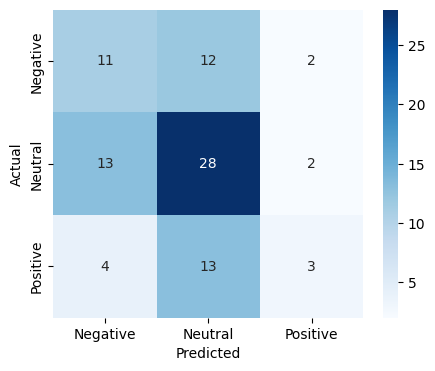

```python
#Confusion Matrix for Test
plot_confusion_matrix(y_test, y_pred_test_base_w2v)
```

```python
#Calculating different metrics on testing data
word2vec_base_test=model_performance_classification_sklearn(rf_word2vec_base, X_test,y_test)
print("Testing performance:\n", word2vec_base_test)
```

```
Testing performance:
    Accuracy    Recall  Precision        F1
0  0.477273  0.477273   0.467157  0.453467
```

```python
print(classification_report(y_test, y_pred_test_base_w2v))
```

```
              precision    recall  f1-score   support

          -1       0.39      0.44      0.42        25
           0       0.53      0.65      0.58        43
           1       0.43      0.15      0.22        20

    accuracy                           0.48        88
   macro avg       0.45      0.41      0.41        88
weighted avg       0.47      0.48      0.45        88
```

Results on Test data are significantly worse than Training data indicating overfitting.

#### RF Model with Grid Search

```python
# Choose the type of classifier.
word2vec_rf_tuned = RandomForestClassifier(class_weight= "balanced",random_state=42,bootstrap=True)

parameters = {
    'max_depth': list(np.arange(5,10,2)),
    'n_estimators': np.arange(50,110,25),
    'max_features': [0.3,0.4]
}

# Run the grid search
grid_obj = GridSearchCV(word2vec_rf_tuned, parameters, scoring='recall',cv=5,n_jobs=-1)
grid_obj = grid_obj.fit(X_train, y_train)

# Set the clf to the best combination of parameters
word2vec_rf_tuned = grid_obj.best_estimator_

# Fit the best algorithm to the data.
word2vec_rf_tuned.fit(X_train, y_train)
```

```
RandomForestClassifier(class_weight='balanced', max_depth=5, max_features=0.3,
                       n_estimators=50, random_state=42)
```

```python
# Predicting on train data
y_pred_train_tuned_w2v = word2vec_rf_tuned.predict(X_train)

# Predicting on test data
y_pred_test_tuned_w2v = word2vec_rf_tuned.predict(X_test)
```

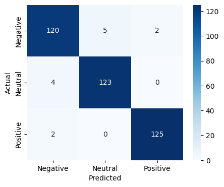

```python
plot_confusion_matrix(y_train, y_pred_train_tuned_w2v)
```

```python
#Calculating different metrics on training data
word2vec_tuned_train=model_performance_classification_sklearn(word2vec_rf_tuned, X_train,y_train)
print("Training performance:\n", word2vec_tuned_train)
```

```
Training performance:
    Accuracy    Recall  Precision        F1
0  0.965879  0.965879   0.965857  0.965858
```

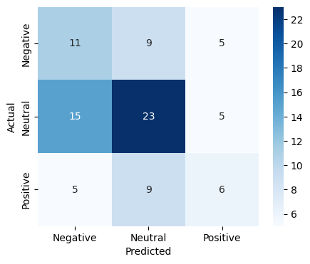

```python
plot_confusion_matrix(y_test, y_pred_test_tuned_w2v)
```

```python
#Calculating different metrics on testing data
word2vec_tuned_test=model_performance_classification_sklearn(word2vec_rf_tuned, X_test,y_test)
print("Testing performance:\n", word2vec_tuned_test)
```

```
Testing performance:
    Accuracy    Recall  Precision        F1
0  0.454545  0.454545   0.460147  0.454951
```

```python
print(classification_report(y_test, y_pred_test_tuned_w2v))
```

```
              precision    recall  f1-score   support

          -1       0.35      0.44      0.39        25
           0       0.56      0.53      0.55        43
           1       0.38      0.30      0.33        20

    accuracy                           0.45        88
   macro avg       0.43      0.42      0.42        88
weighted avg       0.46      0.45      0.45        88
```

### **Random Forest Model with GloVe**

```python
# Storing independent variable
X = df_glove.copy()

# Storing target variable
y = data['Label']
```

```python
# Split data into training and testing set.
X_train_glove, X_test_glove, y_train_glove, y_test_glove = train_test_split(X ,y, test_size = 0.25, random_state = 42, stratify=y)
```

```python
# Apply SMOTE to balance the training data
smote = SMOTE(random_state=42)
X_train_glove, y_train_glove = smote.fit_resample(X_train_glove, y_train_glove)
```

#### RF Base model

```python
# Building the model
rf_glovec_base = RandomForestClassifier(class_weight= "balanced",random_state = 42)

# Fitting on train data
rf_glovec_base.fit(X_train_glove, y_train_glove)
```

```
RandomForestClassifier(class_weight='balanced', random_state=42)
```

```python
# Predicting on train data
y_pred_train_base_gl = rf_glovec_base.predict(X_train_glove)

# Predicting on test data
y_pred_test_base_gl = rf_glovec_base.predict(X_test_glove)
```

```python
plot_confusion_matrix(y_train_glove, y_pred_train_base_gl)
```

[output not shown]

```python
#Calculating different metrics on training data
glove_base_train=model_performance_classification_sklearn(rf_glovec_base, X_train_glove,y_train_glove)
print("Training performance:\n", glove_base_train)
```

```
Training performance:
    Accuracy  Recall  Precision   F1
0       1.0     1.0        1.0  1.0
```

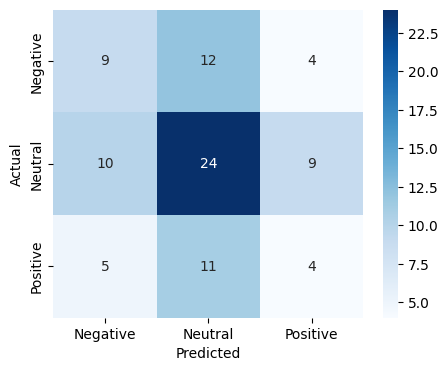

```python
plot_confusion_matrix(y_test_glove, y_pred_test_base_gl)
```

```python
#Calculating different metrics on testing data
glove_base_test=model_performance_classification_sklearn(rf_glovec_base, X_test_glove,y_test_glove)
print("Testing performance:\n", glove_base_test)
```

```
Testing performance:
    Accuracy    Recall  Precision        F1
0  0.420455  0.420455   0.409526  0.414106
```

#### RF Model with Grid Search

```python
# Choose the type of classifier.
glove_rf_tuned = RandomForestClassifier(class_weight= "balanced",random_state=1,bootstrap=True)

parameters = {
    'max_depth': list(np.arange(5,10,2)),
    'n_estimators': np.arange(50,110,25),
    'max_features': [0.3,0.4]
}

# Run the grid search
grid_obj = GridSearchCV(glove_rf_tuned, parameters, scoring='recall',cv=5,n_jobs=-1)
grid_obj = grid_obj.fit(X_train_glove, y_train_glove)

# Set the clf to the best combination of parameters
glove_rf_tuned = grid_obj.best_estimator_

# Fit the best algorithm to the data.
glove_rf_tuned.fit(X_train_glove, y_train_glove)
```

```
RandomForestClassifier(class_weight='balanced', max_depth=5, max_features=0.3,
                       n_estimators=50, random_state=1)
```

```python
# Predicting on train data
y_pred_train_tuned_gl = glove_rf_tuned.predict(X_train_glove)

# Predicting on test data
y_pred_test_tuned_gl = glove_rf_tuned.predict(X_test_glove)
```

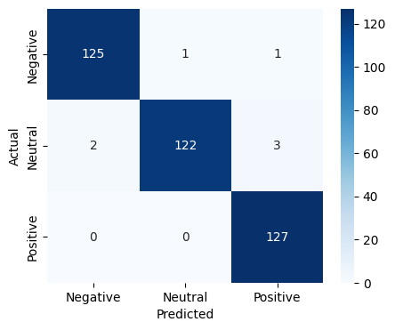

```python
plot_confusion_matrix(y_train_glove, y_pred_train_tuned_gl)
```

```python
#Calculating different metrics on training data
glove_tuned_train=model_performance_classification_sklearn(glove_rf_tuned, X_train_glove,y_train_glove)
print("Training performance:\n", glove_tuned_train)
```

```
Training performance:
    Accuracy    Recall  Precision        F1
0  0.981627  0.981627   0.981863  0.981583
```

```python
print(classification_report(y_train_glove, y_pred_train_tuned_gl))
```

```
              precision    recall  f1-score   support

          -1       0.98      0.98      0.98       127
           0       0.99      0.96      0.98       127
           1       0.97      1.00      0.98       127

    accuracy                           0.98       381
   macro avg       0.98      0.98      0.98       381
weighted avg       0.98      0.98      0.98       381
```

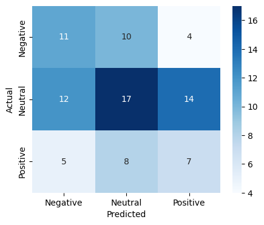

```python
plot_confusion_matrix(y_test_glove, y_pred_test_tuned_gl)
```

```python
#Calculating different metrics on testing data
glove_tuned_test=model_performance_classification_sklearn(glove_rf_tuned, X_test_glove,y_test_glove)
print("Testing performance:\n", glove_tuned_test)
```

```
Testing performance:
    Accuracy    Recall  Precision        F1
0  0.397727  0.397727   0.412581  0.401627
```

```python
print(classification_report(y_test_glove, y_pred_test_tuned_gl))
```

```
              precision    recall  f1-score   support

          -1       0.39      0.44      0.42        25
           0       0.49      0.40      0.44        43
           1       0.28      0.35      0.31        20

    accuracy                           0.40        88
   macro avg       0.39      0.40      0.39        88
weighted avg       0.41      0.40      0.40        88
```

### **Random Forest Model with Sentence Transformer**

```python
#Split the data into Train and Test
X = embedding_matrix
y = data["Label"]
X_train_transformer, X_test_transformer, y_train_transformer, y_test_transformer = train_test_split(X, y, test_size=0.25, random_state=42, stratify=y)
```

```python
# Try reducing to ~80 dimensions to help with overfitting
pca = PCA(n_components=80, random_state=1)
X_train_transformer = pca.fit_transform(X_train_transformer)
X_test_transformer = pca.transform(X_test_transformer)
```

```python
# Apply SMOTE to balance the training data
smote = SMOTE(random_state=42)
X_train_transformer, y_train_transformer = smote.fit_resample(X_train_transformer, y_train_transformer)
```

```python
rf_transformer = RandomForestClassifier(
    class_weight="balanced",
    random_state=1,
    bootstrap=True,
    max_depth=4,           # Start with shallow trees
    min_samples_split=5,   # Require more samples per split
    min_samples_leaf=4,    # Require more samples per leaf
    n_estimators=100,      # More trees for stability
    max_features='sqrt'    # Restrict features per split
)
```

```python
print(X_train_transformer.shape, X_test_transformer.shape)
```

```
(381, 80) (88, 80)
```

```python
print(y_train_transformer.shape, y_test_transformer.shape)
```

```
(381,) (88,)
```

#### RF Base Model

```python
# Building the model
rf_transformer = RandomForestClassifier(n_estimators = 100, max_depth = 7, random_state = 42)
```

```python
# Fitting on train data
rf_transformer.fit(X_train_transformer, y_train_transformer)
```

```
RandomForestClassifier(max_depth=7, random_state=42)
```

```python
# Predicting on train data
y_pred_train_transformer = rf_transformer.predict(X_train_transformer)

# Predicting on test data
y_pred_test_transformer = rf_transformer.predict(X_test_transformer)
```

```python
#Confusion Matrix for Train
plot_confusion_matrix(y_train_transformer, y_pred_train_transformer)
```

[output not shown]

```python
#Calculating different metrics on training data
transformer_base_train=model_performance_classification_sklearn(rf_transformer, X_train_transformer,y_train_transformer)
print("Training performance:\n", transformer_base_train)
```

```
Training performance:
    Accuracy  Recall  Precision   F1
0       1.0     1.0        1.0  1.0
```

```python
print(classification_report(y_train_transformer, y_pred_train_transformer))
```

```
              precision    recall  f1-score   support

          -1       1.00      1.00      1.00       127
           0       1.00      1.00      1.00       127
           1       1.00      1.00      1.00       127

    accuracy                           1.00       381
   macro avg       1.00      1.00      1.00       381
weighted avg       1.00      1.00      1.00       381
```

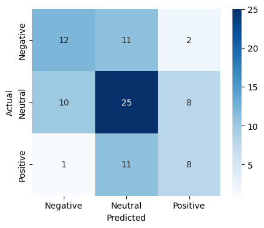

```python
#Confusion Matrix for Test
plot_confusion_matrix(y_test_transformer, y_pred_test_transformer)
```

```python
#Calculating different metrics on testing data
transformer_base_test=model_performance_classification_sklearn(rf_transformer, X_test_transformer,y_test_transformer)
print("Testing performance:\n", transformer_base_test)
```

```
Testing performance:
    Accuracy    Recall  Precision        F1
0  0.511364  0.511364   0.509144  0.509204
```

```python
print(classification_report(y_test_transformer, y_pred_test_transformer))
```

```
              precision    recall  f1-score   support

          -1       0.52      0.48      0.50        25
           0       0.53      0.58      0.56        43
           1       0.44      0.40      0.42        20

    accuracy                           0.51        88
   macro avg       0.50      0.49      0.49        88
weighted avg       0.51      0.51      0.51        88
```

#### RF model with Grid Search

```python
from sklearn.model_selection import StratifiedKFold
```

```python
# Choose the type of classifier.
rf_transformer_tuned = RandomForestClassifier(class_weight= "balanced",random_state=1,bootstrap=True, ccp_alpha=0.01)

# Use stratified k-fold with more folds given small dataset
cv = StratifiedKFold(n_splits=10, shuffle=True, random_state=1)
parameters = {
    'max_depth': [3, 4, 5],
    'min_samples_split': [4, 5, 6],
    'min_samples_leaf': [3, 4, 5],
    'n_estimators': [100],
    'max_features': ['sqrt', 0.2, 0.3]
}

#parameters = {
#    'max_depth': list(np.arange(5,10,2)),
#    'n_estimators': np.arange(50,110,25),
#    'max_features': [0.3,0.4]
#}

# Run the grid search
grid_obj = GridSearchCV(rf_transformer_tuned, parameters, scoring='recall',cv=cv,n_jobs=-1)
grid_obj = grid_obj.fit(X_train_transformer, y_train_transformer)

# Set the clf to the best combination of parameters
rf_transformer_tuned = grid_obj.best_estimator_

# Fit the best algorithm to the data.
rf_transformer_tuned.fit(X_train_transformer, y_train_transformer)
```

```
RandomForestClassifier(ccp_alpha=0.01, class_weight='balanced', max_depth=3,
                       min_samples_leaf=3, min_samples_split=4, random_state=1)
```

```python
# Predicting on train data
y_pred_train_tuned_transformer = rf_transformer_tuned.predict(X_train_transformer)

# Predicting on test data
y_pred_test_tuned_transformer = rf_transformer_tuned.predict(X_test_transformer)
```

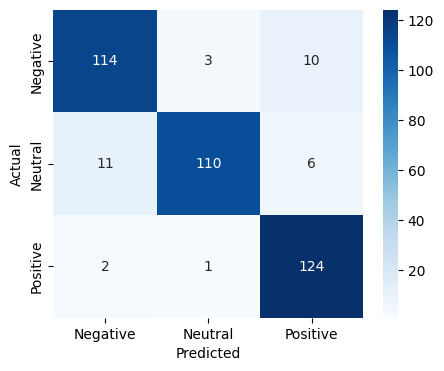

```python
#Confusion Matrix for Train
plot_confusion_matrix(y_train_transformer, y_pred_train_tuned_transformer)
```

```python
#Calculating different metrics on training data
transformer_tuned_train=model_performance_classification_sklearn(rf_transformer_tuned, X_train_transformer,y_train_transformer)
print("Training performance:\n", transformer_tuned_train)
```

```
Training performance:
    Accuracy    Recall  Precision        F1
0  0.913386  0.913386   0.916088  0.913113
```

```python
print(classification_report(y_train_transformer, y_pred_train_tuned_transformer))
```

```
              precision    recall  f1-score   support

          -1       0.90      0.90      0.90       127
           0       0.96      0.87      0.91       127
           1       0.89      0.98      0.93       127

    accuracy                           0.91       381
   macro avg       0.92      0.91      0.91       381
weighted avg       0.92      0.91      0.91       381
```

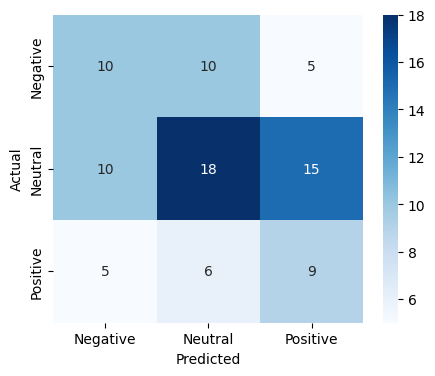

```python
#Confusion Matrix for Test
plot_confusion_matrix(y_test_transformer, y_pred_test_tuned_transformer)
```

```python
#Calculating different metrics on testing data
transformer_tuned_test=model_performance_classification_sklearn(rf_transformer_tuned, X_test_transformer,y_test_transformer)
print("Testing performance:\n", transformer_tuned_test)
```

```
Testing performance:
    Accuracy    Recall  Precision        F1
0  0.420455  0.420455   0.442859  0.425578
```

```python
print(classification_report(y_test_transformer, y_pred_test_tuned_transformer))
```

```
              precision    recall  f1-score   support

          -1       0.40      0.40      0.40        25
           0       0.53      0.42      0.47        43
           1       0.31      0.45      0.37        20

    accuracy                           0.42        88
   macro avg       0.41      0.42      0.41        88
weighted avg       0.44      0.42      0.43        88
```

## **Weekly News Summarization using LLM API**

#### Instructions

**Note**:

- The model is expected to summarize the news from the week by identifying the top three positive and negative events that are most likely to impact the price of the stock.
- As an output, the model is expected to return a JSON containing two keys, one for Positive Events and one for Negative Events.

For the project, we need to define the prompt to be fed to the LLM to help it understand the task to perform. The following should be the components of the prompt:

1. **Role**: Specifies the role the LLM will be taking up to perform the specified task, along with any specific details regarding the role
- **Example**: `You are an expert data analyst specializing in news content analysis.`
2. **Task**: Specifies the task to be performed and outlines what needs to be accomplished, clearly defining the objective
- **Example**: `Analyze the provided news headline and return the main topics contained within it.`
3. **Instructions**: Provides detailed guidelines on how to perform the task, which includes steps, rules, and criteria to ensure the task is executed correctly
- **Example**:

```
Instructions:
1. Read the news headline carefully.
2. Identify the main subjects or entities mentioned in the headline.
3. Determine the key events or actions described in the headline.
4. Extract relevant keywords that represent the topics.
5. List the topics in a concise manner.
```

4. **Output Format**: Specifies the format in which the final response should be structured, ensuring consistency and clarity in the generated output
- **Example**: `Return the output in JSON format with keys as the topic number and values as the actual topic.`

**Full Prompt Example**:

```
You are an expert data analyst specializing in news content analysis.

Task: Analyze the provided news headline and return the main topics contained within it.

Instructions:
1. Read the news headline carefully.
2. Identify the main subjects or entities mentioned in the headline.
3. Determine the key events or actions described in the headline.
4. Extract relevant keywords that represent the topics.
5. List the topics in a concise manner.

Return the output in JSON format with keys as the topic number and values as the actual topic.
```

**Sample Output**:

`{"1": "Politics", "2": "Economy", "3": "Health" }`

**Note:** Attempting to use a locally downloaded LLM proved impractically slow to process results, so instead using an API to access the LLM, in thise case OpenAI's gpt-4o model.

### Setup OpenAI API

```python
#Retrieve API Key
os.environ["OPENAI_API_KEY"] = userdata.get('openai_key')
```

```python
from openai import OpenAI
```

```python
#Initialize the API client
client = OpenAI(
    api_key=os.environ.get("OPENAI_API_KEY"),  # This is the default and can be omitted
)
```

```python
#Perform a basic check to very API is Working
chat_completion = client.chat.completions.create(
    messages=[
        {
            "role": "user",
            "content": "Say this is a test",
        }
    ],
    model="gpt-4o",
)

print(chat_completion.choices[0].message.content)
```

```
This is a test. How can I assist you further?
```

### Load the data and aggregate weekly

```python
from google.colab import drive
drive.mount('/content/drive')
```

```python
# loading data into a pandas dataframe
df = pd.read_csv("/content/drive/MyDrive/Personal/UT Austin/Project 6 - NLP/stock_news.csv")
```

```python
data = df.copy()
```

```python
data["Date"] = pd.to_datetime(data['Date'])  # Convert the 'Date' column to datetime format.
```

```python
# Group the data by week using the 'Date' column.
weekly_grouped = data.groupby(pd.Grouper(key='Date', freq='W'))
```

```python
weekly_grouped = weekly_grouped.agg(
    {
        'News': lambda x: ' || '.join(x)  # Join the news values with ' || ' separator.
    }
).reset_index()

print(weekly_grouped.shape)
```

```
(18, 2)
```

```python
#Verify columns present
weekly_grouped.columns
```

```
Index(['Date', 'News'], dtype='object')
```

```python
#Show row and column count
weekly_grouped.shape
```

```
(18, 2)
```

```python
#Values for the Date column
weekly_grouped['Date']
```

|  | Date |
| --- | --- |
| 0 | 2019-01-06 |
| 1 | 2019-01-13 |
| 2 | 2019-01-20 |
| 3 | 2019-01-27 |
| 4 | 2019-02-03 |
| 5 | 2019-02-10 |
| 6 | 2019-02-17 |
| 7 | 2019-02-24 |
| 8 | 2019-03-03 |
| 9 | 2019-03-10 |
| 10 | 2019-03-17 |
| 11 | 2019-03-24 |
| 12 | 2019-03-31 |
| 13 | 2019-04-07 |
| 14 | 2019-04-14 |
| 15 | 2019-04-21 |
| 16 | 2019-04-28 |
| 17 | 2019-05-05 |

**dtype:** datetime64[ns]

```python
#Preview first two rows
weekly_grouped.head(2)
```

|  | Date | News |
| --- | --- | --- |
| 0 | 2019-01-06 | The tech sector experienced a significant decline in the aftermarket following Apple's Q1 revenue warning. Notable suppliers, including Skyworks, Broadcom, Lumentum, Qorvo, and TSMC, saw their stocks … |
| 1 | 2019-01-13 | Sprint and Samsung plan to release 5G smartphones in nine U.S. cities this summer, with Atlanta, Chicago, Dallas, Houston, Kansas City, Los Angeles, New York City, Phoenix, and Washington D.C. being t… |

```python
#Export weekly_grouped to xlsx
#weekly_grouped.to_excel("/content/drive/MyDrive/Personal/UT Austin/Project 6 - NLP/weekly_grouped.xlsx", index=False)
```

### Defining the Instruction Prompt and Response Function

```python
# defining the instructions for the model
prompt = """
Task: Analyze the provided news headlines that could affect the company's stock price, where headlines are delimited by ||

Instructions:
1. Read the news headlines carefully
2. Identify the top 3 Positive Events
3. Identify the top 3 Negative Events

Return the output in JSON format, strictly using this structure:
{
  "Positive Events": [
    "Summarized Positive Event 1",
    "Summarized Positive Event 2",
    "Summarized Positive Event 3"
  ],
  "Negative Events": [
    "Summarized Negative Event 1",
    "Summarized Negative Event 2",
    "Summarized Negative Event 3"
  ]
}

Do NOT include any extra text outside the JSON structure.
"""
```

````python
#Create a function to call the API with the instruction prompt and news articles as input
def generate_response(prompt, news):
    # Combine instruction prompt and news articles to create a combined prompt
    combined_prompt = f"{news}\n{prompt}"

    try:
        # Generate a response using the OpenAI API
        response = client.chat.completions.create(
            model="gpt-4o",  # Specify the desired model
            messages=[
                {"role": "system", "content": "You are an expert data analyst specializing in news content analysis."},
                {"role": "user", "content": combined_prompt},
            ],
            max_tokens=512,
            temperature=0,
            top_p=0.95,
        )

        # Extract the response content
        response_text = response.choices[0].message.content.strip()

        # Clean up the response text to remove Markdown formatting
        response_text = re.sub(r"```json|```", "", response_text).strip()

        # Post-process the response to ensure valid JSON
        try:
            json_response = json.loads(response_text)
            return json_response
        except json.JSONDecodeError:
            print("Warning: Response is not valid JSON.")
            return {"error": "Invalid JSON response", "raw_response": response_text}

    except client.error.OpenAIError as e:
        print(f"OpenAI API error: {e}")
        return {"error": "API error", "details": str(e)}
````

### Test the Response Function on Sample Data

```python
news = weekly_grouped['News'].iloc[0]
```

```python
generate_response(prompt, news)
```

```
{'Positive Events': ["Roku Inc plans to offer premium video channels through its free streaming service, The Roku Channel, following Amazon's successful Channels business model.",
  'The stock market rebounded strongly on Friday following positive news about US-China trade talks, a better-than-expected jobs report, and dovish comments from Federal Reserve Chairman Jerome Powell.',
  'Oil prices rose on Friday in Asia as China confirmed trade talks with the U.S., with WTI and Brent both gaining.'],
 'Negative Events': ["Apple's Q1 revenue warning led to a significant decline in the tech sector, affecting suppliers like Skyworks, Broadcom, Lumentum, Qorvo, and TSMC.",
  "Apple cut its fiscal first quarter revenue forecast due to weaker demand in China and fewer iPhone upgrades, causing an 8.5% drop in Apple's stock price.",
  'Goldman analyst Rod Hall lowered his price target for Apple from $182 to $140, citing potential risks due to uncertainties in Chinese demand.']}
```

### Run the Model on the Full Data Set and Store Results in a Dataframe

```python
# Initialize a list to store results
results = []

# Loop through each row of weekly_grouped
for _, row in weekly_grouped.iterrows():
    date = row['Date']
    news_content = row['News']

    # Call the API to analyze the news content
    analysis_results = generate_response(prompt, news_content)
    #print(analysis_results)

    # Extract results from the API response
    if 'error' not in analysis_results:
        pos_events = analysis_results.get('Positive Events', [""] * 3)  # Default to empty strings
        neg_events = analysis_results.get('Negative Events', [""] * 3)  # Default to empty strings
    else:
        # Handle invalid JSON or errors
        pos_events = ["Error"] * 3
        neg_events = ["Error"] * 3

    # Append the results to the list
    results.append({
        'Date': date,
        'PosEvent1': pos_events[0],
        'PosEvent2': pos_events[1],
        'PosEvent3': pos_events[2],
        'NegEvent1': neg_events[0],
        'NegEvent2': neg_events[1],
        'NegEvent3': neg_events[2],
    })

# Create the results DataFrame from the list
news_analysis_results = pd.DataFrame(results)
```

```python
news_analysis_results.columns
```

```
Index(['Date', 'PosEvent1', 'PosEvent2', 'PosEvent3', 'NegEvent1', 'NegEvent2',
       'NegEvent3'],
      dtype='object')
```

```python
#Row and column count of news_analysis_results
print(news_analysis_results.shape)
```

```
(18, 7)
```

```python
# Preview the first 3 rows
print(news_analysis_results.head(3))
```

```
        Date  \
0 2019-01-06
1 2019-01-13
2 2019-01-20

                                                                                                                                                     PosEvent1  \
0  Roku Inc plans to offer premium video channels through its free streaming service, The Roku Channel, following Amazon's successful Channels business model.
1                                                      Sprint and Samsung plan to release 5G smartphones in nine U.S. cities, enhancing their market presence.
2                                          Dialog Semiconductor shares rose 4% as investors praised its resilience amid other Apple suppliers missing targets.

                                                                                                                                                                                                PosEvent2  \
0  The stock market rebounded strongly on Friday following positive news about US-China trade talks, a better-than-expected jobs report, and dovish comments from Federal Reserve Chairman Jerome Powell.
1                                                                                Deutsche Bank upgraded Vivendi's Universal Music Group valuation, indicating strong growth potential in music streaming.
2                                                          U.S. stocks rose on Tuesday with technology and internet companies leading gains after Netflix announced a price increase for U.S subscribers.

                                                                                                                                         PosEvent3  \
0                                 Oil prices rose on Friday in Asia as China confirmed trade talks with the U.S., with WTI and Brent both gaining.
1                               The S&P 500 reached a three-week high driven by gains in major tech stocks and optimism over US-China trade talks.
2  Verizon announced that it will offer free Apple Music subscriptions with some of its top tier data plans, deepening its partnership with Apple.

                                                                                                                                                 NegEvent1  \
0      Apple's Q1 revenue warning led to a significant decline in the tech sector, affecting suppliers like Skyworks, Broadcom, Lumentum, Qorvo, and TSMC.
1                           Roku's stock dropped by 5% after Citron Research labeled the company as uninvestable due to Apple's partnerships with Samsung.
2  U.S. stock market declined on Monday as concerns over a global economic slowdown intensified following unexpected drops in China's exports and imports.

                                                                                                                                                                   NegEvent2  \
0                  Apple cut its fiscal first quarter revenue forecast due to weaker demand in China and fewer iPhone upgrades, causing an 8.5% drop in Apple's stock price.
1                                                                          Foxconn reported an 8.3% decline in December revenue due to weak demand for consumer electronics.
2  Apple Inc. shares declined in postmarket trading after announcing it would cut back on hiring for some divisions due to fewer iPhone sales and missing revenue forecasts.

                                                                                                                                                                        NegEvent3
0  Goldman analyst Rod Hall lowered his price target for Apple from $182 to $140, citing potential risks to the tech giant's 2019 numbers due to uncertainties in Chinese demand.
1                                                              Several Chinese retailers drastically reduced iPhone prices due to weak sales in China, impacting Apple's revenue.
2                                                     Foxconn, Apple's biggest iPhone assembler, has let go around 50,000 contract workers in China earlier than usual this year.
```

## **Weekly News Summarization using Locally Downloaded LLM**

In this section we show how to load an LLM (Mistral), however, we don't actually run this model as the time to process results proved to be unacceptably slow on the compute platform available in Google Colab (T4 GPU). A search on this question yielded the following answer: *A Mistral 7B model running very slowly on Google Colab is likely due to the large size of the model, which puts significant demands on the limited memory and processing power available on the free Colab tier, making it impractical to run efficiently without utilizing optimization techniques like model loading strategies or upgrading to a paid Colab plan with more powerful GPUs; essentially, the free Colab environment might not have enough resources to handle the computational needs of a 7 billion parameter model like Mistral 7B.*

```python
#Updated recommended by GL for llama_cpp
!CMAKE_ARGS="-DLLAMA_CUBLAS=on" FORCE_CMAKE=1 pip install llama-cpp-python==0.1.85 --force-reinstall --no-cache-dir -q
```

[output not shown]

```python
# Function to download the model from the Hugging Face model hub
from huggingface_hub import hf_hub_download

# Importing the Llama class from the llama_cpp module
from llama_cpp import Llama

# Importing the library for data manipulation
import pandas as pd

from tqdm import tqdm # For progress bar related functionalities
tqdm.pandas()
```

### Utility Functions

```python
# defining a function to parse the JSON output from the model
def extract_json_data(json_str):
    import json
    try:
        # Find the indices of the opening and closing curly braces
        json_start = json_str.find('{')
        json_end = json_str.rfind('}')

        if json_start != -1 and json_end != -1:
            extracted_category = json_str[json_start:json_end + 1]  # Extract the JSON object
            data_dict = json.loads(extracted_category)
            return data_dict
        else:
            print(f"Warning: JSON object not found in response: {json_str}")
            return {}
    except json.JSONDecodeError as e:
        print(f"Error parsing JSON: {e}")
        return {}
```

```python
#Defining the response function
def response_mistral(prompt, news):
    model_output = llm(
      f"""
      [INST]
      {prompt}
      News Articles: {news}
      [/INST]
      """,
      max_tokens=32, #Complete the code to set the maximum number of tokens the model should generate for this task.
      temperature=0.7, #Determines the randomness of the model's output.
      top_p=0.9, #Nucleus sampling controls the diversity of tokens considered during generation.
      top_k=50, #Restricts token sampling to the top k tokens based on probability.
      echo=False,
    )

    final_output = model_output["choices"][0]["text"]

    return final_output
```

### Loading the model (Mistral)

```python
model_name_or_path = "TheBloke/Mistral-7B-Instruct-v0.2-GGUF"
model_basename = "mistral-7b-instruct-v0.2.Q6_K.gguf"
```

```python
model_path = hf_hub_download(
    repo_id=model_name_or_path,
    filename=model_basename
)
```

```python
# Load the model
llm = Llama(
    model_path=model_path,
    n_threads=4,
    n_batch=512,
    n_gpu_layers=30,
    n_ctx=4096  # Adjust context window as needed
)
```

```
AVX = 1 | AVX2 = 1 | AVX512 = 0 | AVX512_VBMI = 0 | AVX512_VNNI = 0 | FMA = 1 | NEON = 0 | ARM_FMA = 0 | F16C = 1 | FP16_VA = 0 | WASM_SIMD = 0 | BLAS = 1 | SSE3 = 1 | SSSE3 = 1 | VSX = 0 |
```

## **Conclusions and Recommendations**

In the **Sentiment Analysis** Exercise, all 3 approaches, Word2Vec, GloVe, and Sentence Transformer tended to lead to overfitting. Based on some research I did the impression seems to be that having only 349 samples along with the very high dimensionality of the encodings (100 features for Word2Vec and GloVe and 384 features for all-MiniLM-L6-v2) is problematic for machine learning models like Random Forests, namely severe overfitting. There were also struggles with getting the GridSearch to achieve better results than just the base Random Forest models.

In the **Summarization Exercise**, very good results and performance were achieved using the Open AI API with gpt-4o model. Unfortunately I was not able to test out using a locally downloaded LLM from HuggingFace, because in each case I could not get reasonable reponse times. E.g., when trying to use the Llama 7B model it was taking 50 minutes to get a response from just a simple test prompt. Not sure if this is something to do with limitations in the Google Colab environment even when using GPU (T4).